# Cleaning and tidying data in R

In this workshop, we will meet the following tools:

- *R Notebook*
- *Data manipulation packages in R*
- *LOGO plots in R using `ggseqlogo`.*

## **Initial tools**

**R Notebooks**  
An [R Markdown](http://rmarkdown.rstudio.com) Notebook is a useful tool for documenting analysis methods and their output. When you execute code within the notebook, the results appear beneath the code.  
We will work with this format for the convience of code reproducability and immediate output. To run a block you can either click the *Run* button within the chunk (right-hand side) or by placing your cursor inside it and pressing *Ctrl+Shift+Enter*. To add a new chunk you can click the *Insert Chunk* button on the toolbar or press *Ctrl+Alt+I*.

**Datasets**  
We will be experimenting with the [`diamonds`](https://ggplot2.tidyverse.org/reference/diamonds.html) dataset, a built-in dataset as a part of the `ggplot2` library.

```r
library(ggplot2) # load the ggplot2 library
source("/home/alu/fulther/Scripts/scripts_R/General/plotting_functions.R") # source file with self-built functions
```

Notice the line sourcing an R script - this is a file with many functions I wrote for easy plotting - you’re welcome to use them. Sourcing an R file will allow usage of its functions within the current script. Let’s take a look at our dataset:

```r
head(diamonds)
```

| carat | cut | color | clarity | depth | table | price | x | y | z |
| --- | --- | --- | --- | --- | --- | --- | --- | --- | --- |
| 0.23 | Ideal | E | SI2 | 61.5 | 55 | 326 | 3.95 | 3.98 | 2.43 |
| 0.21 | Premium | E | SI1 | 59.8 | 61 | 326 | 3.89 | 3.84 | 2.31 |
| 0.23 | Good | E | VS1 | 56.9 | 65 | 327 | 4.05 | 4.07 | 2.31 |
| 0.29 | Premium | I | VS2 | 62.4 | 58 | 334 | 4.20 | 4.23 | 2.63 |
| 0.31 | Good | J | SI2 | 63.3 | 58 | 335 | 4.34 | 4.35 | 2.75 |
| 0.24 | Very Good | J | VVS2 | 62.8 | 57 | 336 | 3.94 | 3.96 | 2.48 |

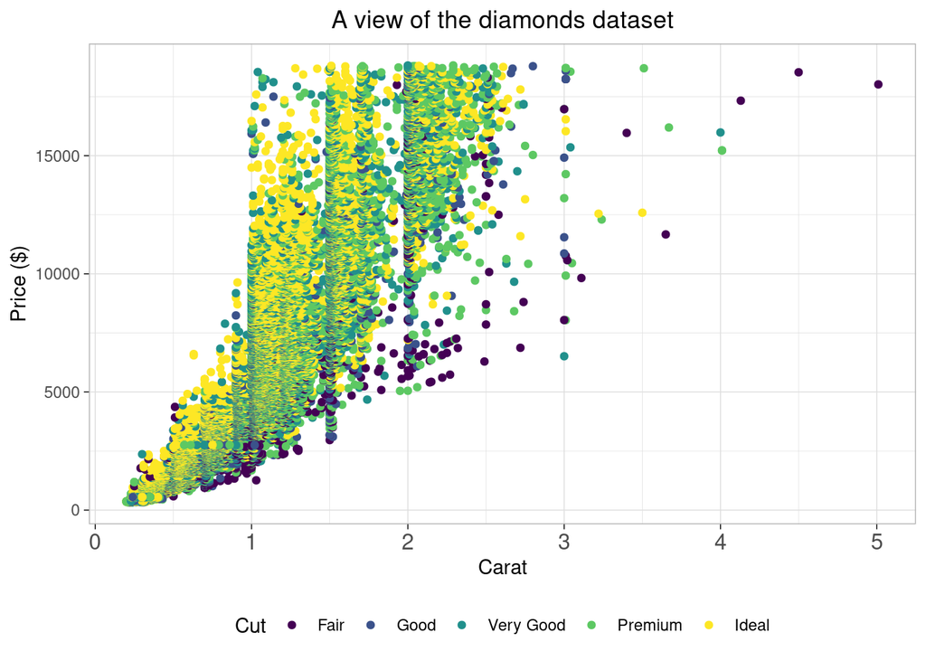

```r
scatterPlot(diamonds, xcol = diamonds$carat, ycol = diamonds$price, fillcol = diamonds$cut,
        title = "A view of the diamonds dataset", xlab = "Carat", ylab = "Price ($)", colorlab = "Cut")
```

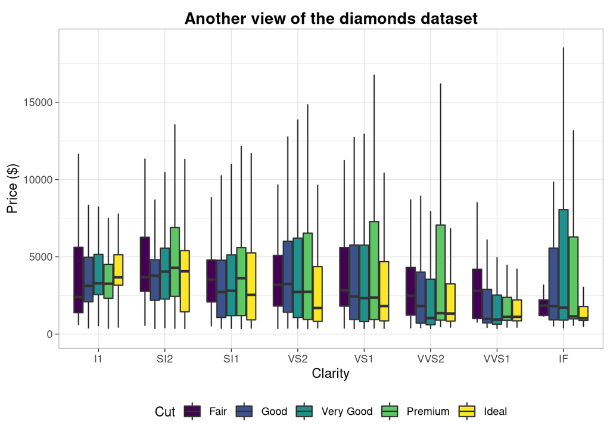

```r
boxPlot(diamonds, xcol = diamonds$clarity, ycol = diamonds$price, fillcol = diamonds$cut,
        title = "Another view of the diamonds dataset", xlab = "Clarity", ylab = "Price ($)", filllab = "Cut", show_points = F) + theme(legend.position = "bottom")
```

**Tools & packages**  
To tidy the data and prepare it for further analysis we will use the `tidyverse` collection and `reshape2`. The [`tidyverse` collection](https://www.tidyverse.org/) includes `ggplot2`, `dplyr`, `tidyr` and more, all written by the data scientist Hadley Wickham. All packages in this collection share a common design philosophy, grammar and data structure. The `reshape2` package is a bit similar to `tidyr` in function, with slightly different syntax and actions.

## **Tidy data**

Credit: https://r4ds.had.co.nz/tidy-data.html  
You can represent the same underlying data in multiple ways. Each of the following datasets shows the same values of four variables country, year, population, and cases (of tuberculosis), but each dataset organises the values in a different way.  
These are all representations of the same underlying data, but they are not equally easy to use. One dataset, the tidy dataset, will be much easier to work with inside the `tidyverse`. Which?

```r
library(tidyr)
table1
```

| country | year | cases | population |
| --- | --- | --- | --- |
| Afghanistan | 1999 | 745 | 19987071 |
| Afghanistan | 2000 | 2666 | 20595360 |
| Brazil | 1999 | 37737 | 172006362 |
| Brazil | 2000 | 80488 | 174504898 |
| China | 1999 | 212258 | 1272915272 |
| China | 2000 | 213766 | 1280428583 |

```r
table2
```

| country | year | type | count |
| --- | --- | --- | --- |
| Afghanistan | 1999 | cases | 745 |
| Afghanistan | 1999 | population | 19987071 |
| Afghanistan | 2000 | cases | 2666 |
| Afghanistan | 2000 | population | 20595360 |
| Brazil | 1999 | cases | 37737 |
| Brazil | 1999 | population | 172006362 |
| Brazil | 2000 | cases | 80488 |
| Brazil | 2000 | population | 174504898 |
| China | 1999 | cases | 212258 |
| China | 1999 | population | 1272915272 |

[output cut: 2 more lines]

```r
table3
```

|  | country | year | rate |
| --- | --- | --- | --- |
| 1 | Afghanistan | 1999 | 745/19987071 |
| 2 | Afghanistan | 2000 | 2666/20595360 |
| 3 | Brazil | 1999 | 37737/172006362 |
| 4 | Brazil | 2000 | 80488/174504898 |
| 5 | China | 1999 | 212258/1272915272 |
| 6 | China | 2000 | 213766/1280428583 |

```r
table4a # cases
```

|  | country | 1999 | 2000 |
| --- | --- | --- | --- |
| 1 | Afghanistan | 745 | 2666 |
| 2 | Brazil | 37737 | 80488 |
| 3 | China | 212258 | 213766 |

```r
table4b # population
```

|  | country | 1999 | 2000 |
| --- | --- | --- | --- |
| 1 | Afghanistan | 19987071 | 20595360 |
| 2 | Brazil | 172006362 | 174504898 |
| 3 | China | 1272915272 | 1280428583 |

### Tidyness rules

There are three interrelated rules which make a dataset tidy, as defined by Hadley Wickham:

1. Each **variable** must have its own column.
2. Each **observation** must have its own row.
3. Each **value** must have its own cell.

These three rules are interrelated because it’s impossible to only satisfy two of the three.  
Why ensure that your data is tidy? There are two main advantages:

- One consistent way of storing data
- Placing variables in columns is highly compatible with R’s vectorised nature, as most built-in R functions work with vectors of values.

### Long and wide data formats

`table1` and `table2` represent the wide and long formats of the same data.  
*Wide data* has a column for each variable.  
*Long (or narrow) data* has a column for possible variable types & a column for the values of those variables.  
Which is preferred for tidy data as previously defined?

## **Tidy tools**

Let’s look at some tools for tidying our data.

### Data management and analysis: dplyr

First, meet `dplyr`. This package is your right-hand in all data analysis. It’s major features are using relatively simple syntax to cover up base R’s unintuitive one, the neat pipe operator (`%>%`), and the grouping feature. It allows preforming tasks such as:

- **select** specific features (columns) of interest from the data set
- **filter** out irrelevant data and only keep observations (rows) of interest
- **mutate** a data set by adding more features (columns)
- **arrange** the observations (rows) in a particular order
- **summarize** the data in terms of aspects such as the mean, median, or maximum
- **join** multiple data sets together into a single data frame

**Basic syntax examples:**

```r
library(dplyr)
```

```r
# take certain columns
diamonds[, c("cut", "color", "price")] # baseR
select(diamonds, cut, color, price) # dplyr

# take only columns that start with a "c"
diamonds[, grep("^c", colnames(diamonds))] # baseR
select(diamonds, starts_with("c")) # dplyr

# subset certain rows (ideal cut, either E or J in color, within certain price range)
diamonds[diamonds$cut == "Ideal" & (diamonds$color == "E" | diamonds$color == "J") & diamonds$price > 1000 & diamonds$price < 10000, ] # baseR
filter(diamonds, cut == "Ideal", color == "E" | color == "J", price > 1000, price < 10000) # dplyr

# add or change column
diamonds$price_per_carat <- diamonds$price / diamonds$carat # baseR: acts on data frame / tibble, no output here
mutate(diamonds, price_per_carat = price / carat) # dplyr: returns new data frame, and will be printed
```

There are many `select()` helpers: `contains()`, `matches()`, `ends_with()`, `one_of()`, `everything()` (used for rearranging columns) and more. Now let’s add the `%>%` option! Just like shell pipe, this takes the output of the last command and inputs it to the next:

```r
diamonds %>%
  select(cut, color, price)
```

| cut | color | price |
| --- | --- | --- |
| Ideal | E | 326 |
| Premium | E | 326 |
| Good | E | 327 |
| Premium | I | 334 |
| Good | J | 335 |
| Very Good | J | 336 |
| Very Good | I | 336 |
| Very Good | H | 337 |
| Fair | E | 337 |
| Very Good | H | 338 |

[output cut: 9990 more lines]

Notice we don’t give `diamonds` as an input to `select()`, because each method uses the input from the previous step. Now that you’ve seen some commands and features, try it yourself!  
Create a one-liner (no temporary variables!) that outputs a table with the price per carat of ideal-cut diamonds of all colors, with a price under 500$.  
For bonus points, arrange the results in descending order according to price.

| carat | cut | color | price | price_per_carat |
| --- | --- | --- | --- | --- |
| 0.30 | Ideal | F | 499 | 1663.333 |
| 0.30 | Ideal | F | 499 | 1663.333 |
| 0.30 | Ideal | F | 499 | 1663.333 |
| 0.30 | Ideal | E | 499 | 1663.333 |
| 0.30 | Ideal | E | 499 | 1663.333 |
| 0.30 | Ideal | E | 499 | 1663.333 |
| 0.30 | Ideal | E | 499 | 1663.333 |
| 0.30 | Ideal | E | 499 | 1663.333 |
| 0.30 | Ideal | E | 499 | 1663.333 |
| 0.30 | Ideal | E | 499 | 1663.333 |

[output cut: 618 more lines]

**Grouping and summrizing:**  
The next two features are much harder to implement in base R, but pretty straightforward. `summarise()` sums up different statistics into a new data frame, and `group_by()` considers certain groups while acting.

```r
# we name the column mean_price, the default name (unassigned action) is action(variable): mean(price)
diamonds %>%
  summarise(mean_price = mean(price),
            median_price = median(price),
            count = n())
```

| mean_price | median_price | count |
| --- | --- | --- |
| 3932.8 | 2401 | 53940 |

```r
# now lets get the mean for all numeric variables
diamonds %>%
  summarise_if(is.numeric, mean, na.rm = TRUE)
```

| carat | depth | table | price | x | y | z |
| --- | --- | --- | --- | --- | --- | --- |
| 0.7979397 | 61.7494 | 57.45718 | 3932.8 | 5.731157 | 5.734526 | 3.538734 |

```r
# add a grouping variable
diamonds %>%
  group_by(cut) %>%
  summarise_if(is.numeric, mean, na.rm = TRUE)
```

| cut | carat | depth | table | price | x | y | z |
| --- | --- | --- | --- | --- | --- | --- | --- |
| Fair | 1.0461366 | 64.04168 | 59.05379 | 4358.758 | 6.246894 | 6.182652 | 3.982770 |
| Good | 0.8491847 | 62.36588 | 58.69464 | 3928.864 | 5.838785 | 5.850744 | 3.639507 |
| Very Good | 0.8063814 | 61.81828 | 57.95615 | 3981.760 | 5.740696 | 5.770026 | 3.559801 |
| Premium | 0.8919549 | 61.26467 | 58.74610 | 4584.258 | 5.973887 | 5.944879 | 3.647124 |
| Ideal | 0.7028370 | 61.70940 | 55.95167 | 3457.542 | 5.507451 | 5.520080 | 3.401448 |

```r
# add two grouping variables and two functions
diamonds %>%
  group_by(cut, color) %>%
  summarise_at(c("carat", "price"), c(mean=mean, median=median), na.rm = TRUE)
```

| cut | color | carat_mean | price_mean | carat_median | price_median |
| --- | --- | --- | --- | --- | --- |
| Fair | D | 0.9201227 | 4291.061 | 0.900 | 3730.0 |
| Fair | E | 0.8566071 | 3682.312 | 0.900 | 2956.0 |
| Fair | F | 0.9047115 | 3827.003 | 0.900 | 3035.0 |
| Fair | G | 1.0238217 | 4239.255 | 0.980 | 3057.0 |
| Fair | H | 1.2191749 | 5135.683 | 1.010 | 3816.0 |
| Fair | I | 1.1980571 | 4685.446 | 1.010 | 3246.0 |
| Fair | J | 1.3411765 | 4975.655 | 1.030 | 3302.0 |
| Good | D | 0.7445166 | 3405.382 | 0.700 | 2728.5 |
| Good | E | 0.7451340 | 3423.644 | 0.700 | 2420.0 |
| Good | F | 0.7759296 | 3495.750 | 0.710 | 2647.0 |

[output cut: 25 more lines]

```r
# find correlation
diamonds %>%
  group_by(clarity) %>%
  summarise(p_value = cor.test(price, carat, method = "pearson")$p.value,
            r = cor.test(price, carat, method = "pearson")$estimate)
```

| clarity | p_value | r |
| --- | --- | --- |
| I1 | 0 | 0.9485698 |
| SI2 | 0 | 0.9544026 |
| SI1 | 0 | 0.9574561 |
| VS2 | 0 | 0.9523743 |
| VS1 | 0 | 0.9502273 |
| VVS2 | 0 | 0.9484739 |
| VVS1 | 0 | 0.9404173 |
| IF | 0 | 0.9294814 |

Now hands-on!  
Let’s use the `diamonds` dataset to conduct a little experiment: for each diamond cut, we would like to find the *mean*, *median* and *standard deviation* of the estimated diamond size and price. Assume the estimated size can be calculated as a product of the given diamon dimentions (`x`, `y`, `z`).  
We also want to know if there is a linear correlation between the estimated size and the `table` measurement, for each diamond cut and color. For the extra effort - see if you can use `p.adjust()` and the tools we learned to correct the p-values and find the significant ones!

### Tidying data: reshape2 and tidyr

As previously stated, `tidyr` (part of the `tidyverse` collection) and `reshape2` share similar features. They mainly focus on tidiyng the data, rather than manipulation, and more specifically - moveing between long and wide formats. Going back to the original data shown, we can see only one table is in a tidy format - according to the **variable-observation-value** principle.

```r
table1
```

| country | year | cases | population |
| --- | --- | --- | --- |
| Afghanistan | 1999 | 745 | 19987071 |
| Afghanistan | 2000 | 2666 | 20595360 |
| Brazil | 1999 | 37737 | 172006362 |
| Brazil | 2000 | 80488 | 174504898 |
| China | 1999 | 212258 | 1272915272 |
| China | 2000 | 213766 | 1280428583 |

Taking a look at `table4a` and `table4b` we can see that some of the column names are not names of variables, but *values* of a variable. The column names `1999` and `2000` represent values of the `year` variable, and the values in these columns represent values of the `cases` variable, and each row represents two observations, not one. To fix this, we want to pivot this data into **long format**, using `melt()` and `pivot_longer()`.

```r
table4a # cases
```

|  | country | 1999 | 2000 |
| --- | --- | --- | --- |
| 1 | Afghanistan | 745 | 2666 |
| 2 | Brazil | 37737 | 80488 |
| 3 | China | 212258 | 213766 |

```r
table4b # population
```

|  | country | 1999 | 2000 |
| --- | --- | --- | --- |
| 1 | Afghanistan | 19987071 | 20595360 |
| 2 | Brazil | 172006362 | 174504898 |
| 3 | China | 1272915272 | 1280428583 |

```r
library(reshape2) # masks something from tidyr
library(tidyr)

melt(table4a, id.vars = "country", value.name = "cases", variable.name = "year") # reshape2
```

| country | year | cases |
| --- | --- | --- |
| Afghanistan | 1999 | 745 |
| Brazil | 1999 | 37737 |
| China | 1999 | 212258 |
| Afghanistan | 2000 | 2666 |
| Brazil | 2000 | 80488 |
| China | 2000 | 213766 |

```r
pivot_longer(table4a, names_to = "year", values_to = "cases", -country) # tidyr
```

| country | year | cases |
| --- | --- | --- |
| Afghanistan | 1999 | 745 |
| Afghanistan | 2000 | 2666 |
| Brazil | 1999 | 37737 |
| Brazil | 2000 | 80488 |
| China | 1999 | 212258 |
| China | 2000 | 213766 |

```r
# if we do the same for table4b and merge the tables together
merge(melt(table4a, id.vars = "country", value.name = "cases", variable.name = "year"),
      pivot_longer(table4b, names_to = "year", values_to = "population", -country),
      by = c("country", "year"))
```

| country | year | cases | population |
| --- | --- | --- | --- |
| Afghanistan | 1999 | 745 | 19987071 |
| Afghanistan | 2000 | 2666 | 20595360 |
| Brazil | 1999 | 37737 | 172006362 |
| Brazil | 2000 | 80488 | 174504898 |
| China | 1999 | 212258 | 1272915272 |
| China | 2000 | 213766 | 1280428583 |

Let’s see what can be done about `table2`. It isn’t far off, it satisfies the **value** rule. Unfortunately, there are two rows per observation and a single `type` column for two variables. So in this case, we need to change the long format into wide.  
Come to our help - `dcast()` and `pivot_wider()`!

```r
table2
```

| country | year | type | count |
| --- | --- | --- | --- |
| Afghanistan | 1999 | cases | 745 |
| Afghanistan | 1999 | population | 19987071 |
| Afghanistan | 2000 | cases | 2666 |
| Afghanistan | 2000 | population | 20595360 |
| Brazil | 1999 | cases | 37737 |
| Brazil | 1999 | population | 172006362 |
| Brazil | 2000 | cases | 80488 |
| Brazil | 2000 | population | 174504898 |
| China | 1999 | cases | 212258 |
| China | 1999 | population | 1272915272 |

[output cut: 2 more lines]

```r
dcast(table2, country+year ~ type, value.var = "count") # reshape2
```

| country | year | cases | population |
| --- | --- | --- | --- |
| Afghanistan | 1999 | 745 | 19987071 |
| Afghanistan | 2000 | 2666 | 20595360 |
| Brazil | 1999 | 37737 | 172006362 |
| Brazil | 2000 | 80488 | 174504898 |
| China | 1999 | 212258 | 1272915272 |
| China | 2000 | 213766 | 1280428583 |

```r
pivot_wider(table2, names_from = type, values_from = count) # tidyr
```

| country | year | cases | population |
| --- | --- | --- | --- |
| Afghanistan | 1999 | 745 | 19987071 |
| Afghanistan | 2000 | 2666 | 20595360 |
| Brazil | 1999 | 37737 | 172006362 |
| Brazil | 2000 | 80488 | 174504898 |
| China | 1999 | 212258 | 1272915272 |
| China | 2000 | 213766 | 1280428583 |

Finally, let’s fix `table3`. We need to separate the `rate` column into `cases` and `population`.

```r
table3
```

|  | country | year | rate |
| --- | --- | --- | --- |
| 1 | Afghanistan | 1999 | 745/19987071 |
| 2 | Afghanistan | 2000 | 2666/20595360 |
| 3 | Brazil | 1999 | 37737/172006362 |
| 4 | Brazil | 2000 | 80488/174504898 |
| 5 | China | 1999 | 212258/1272915272 |
| 6 | China | 2000 | 213766/1280428583 |

```r
# notice tha colsplit only splits the string vector and does not return a data frame
# while separate returns the full data frame
colsplit(string = table3$rate, pattern = "/", names = c("cases", "population")) # reshape2
```

| cases | population |
| --- | --- |
| 745 | 19987071 |
| 2666 | 20595360 |
| 37737 | 172006362 |
| 80488 | 174504898 |
| 212258 | 1272915272 |
| 213766 | 1280428583 |

```r
separate(table3, rate, sep = "/", into = c("cases", "population")) # tidyr
```

| country | year | cases | population |
| --- | --- | --- | --- |
| Afghanistan | 1999 | 745 | 19987071 |
| Afghanistan | 2000 | 2666 | 20595360 |
| Brazil | 1999 | 37737 | 172006362 |
| Brazil | 2000 | 80488 | 174504898 |
| China | 1999 | 212258 | 1272915272 |
| China | 2000 | 213766 | 1280428583 |

Which is more convinient? That is up to you! Some prefer the old-fashioned, simple syntax of `reshape2`, and some favor the many options and possibilies of `tidyr`.  
Now, let’s do some bioinformatics! Our goal is to generate a LOGO plot (code given below). Use the given code to generate a table in the following format:

|  | Base | -1 | 0 | 1 |
| --- | --- | --- | --- | --- |
| 1 | A | 0.32962182 | 1 | 0.2669102 |
| 2 | C | 0.30366483 | 0 | 0.2132409 |
| 3 | G | 0.07388167 | 0 | 0.3756316 |
| 4 | T | 0.29283169 | 0 | 0.1442173 |

The initial table looks like this:

```r
library(stringi)
data.frame(Sample = c(1:500), Sequence = paste0(stri_rand_strings(500, 1, pattern = "[ACG]"), ";",
                                                stri_rand_strings(500, 1, pattern = "[ACTG]"), ";",
                                                stri_rand_strings(500, 1, pattern = "[TG]")))
```

| Sample | Sequence |
| --- | --- |
| 1 | A;G;G |
| 2 | A;C;T |
| 3 | C;G;T |
| 4 | C;C;G |
| 5 | C;A;T |
| 6 | C;T;T |
| 7 | G;G;G |
| 8 | A;C;T |
| 9 | A;T;G |
| 10 | C;G;G |

[output cut: 490 more lines]

To deal with NA values, the `replace_na()` method from `tidyr` can be used. It accepts a list of column names and the relevant replacement value: `replace_na(data, list("colA" = 0.5, "colB" = "noSuchThing"))`.

Once the correct format is achieved, use this `ggseqlogo` code to plot a LOGO graph of the data (for input data frame `logo_data`):

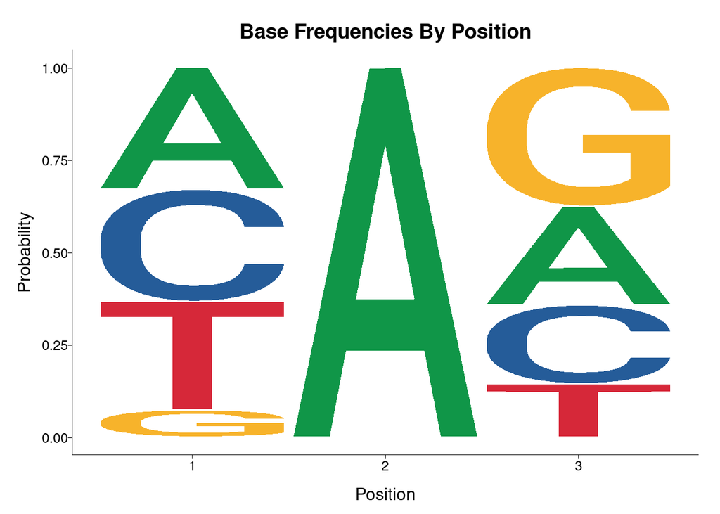

```r
rownames(logo_data) <- logo_data$Base # set row names to be base name as required
logo_data <- select(logo_data, -Base) # remove the base name column
# notice that data frame muts be coerced into matrix
library(ggseqlogo)
ggseqlogo(data = as.matrix(logo_data), method = 'prob') +
  ylab("Probability") +
  xlab("Position") +
  ggtitle("Base Frequencies By Position") +
  theme(axis.line = element_line(size = 0.2),
        axis.ticks = element_line(size = 0.2),
        plot.title = element_text(hjust = 0.5, vjust = 0.5, face = "bold"),
        axis.title.x = element_text(vjust = -2),
        axis.title.y = element_text(vjust = 2),
        plot.margin = unit(c(15, 15, 15, 15), "points"))
```

# **References**

https://r4ds.had.co.nz/tidy-data.html https://blog.rstudio.com/2014/07/22/introducing-tidyr/ http://www.milanor.net/blog/reshape-data-r-tidyr-vs-reshape2/ https://jtr13.github.io/spring19/hx2259_qz2351.html#:~:text=gather()%20vs%20melt()&text=We%20could%20see%20that%20the,a%20correct%20long%20form%20dataset.&text=variable%20for%20both%20functions%20as%20below. https://omarwagih.github.io/ggseqlogo/

# **Cheat sheets**

Data import -`tidyr` cheat sheet: https://github.com/rstudio/cheatsheets/blob/master/data-import.pdf R markdown and notebook formats: https://rmarkdown.rstudio.com/authoring_basics.html